# Homework #3

Gbemisola Talabi

1 November 2022

### **Instructions**

1. Please submit your knitted `.pdf` file to the assignment drop box on eLC. If you are still having trouble knitting your file you can submit your `.Rmd` file.
2. The assignment is due November 1, 2022 by 7:00pm EST. This assignment will be graded for accuracy. Please reach out to us if you need help before this time!
3. Please add your name as “author” to the YAML header above.
4. Below each question is a `r` code chunk that can be used to explore the question. Use the space below the code chunk to directly answer the question.

```r
## you can add more, or change...
rm(list=ls(all=T))

library(tidyverse)
library(RColorBrewer)
library(naniar)
```

### **Problem Set**

```r
sero <- read_rds("../data/serodata.rds")
glimpse(sero)
```

```
## Rows: 651
## Columns: 4
## $ IgG_concentration <dbl> 0.31768953, 3.43682310, 0.30000000, 143.23630137, 0.…
## $ age               <dbl> 2, 4, 4, 4, 1, 4, 4, 2, 4, 2, 3, 15, 8, 12, 15, 9, 8…
## $ gender            <chr> "Female", "Female", "Male", "Male", "Male", "Male", …
## $ slum              <chr> "Non slum", "Non slum", "Non slum", "Non slum", "Non…
```

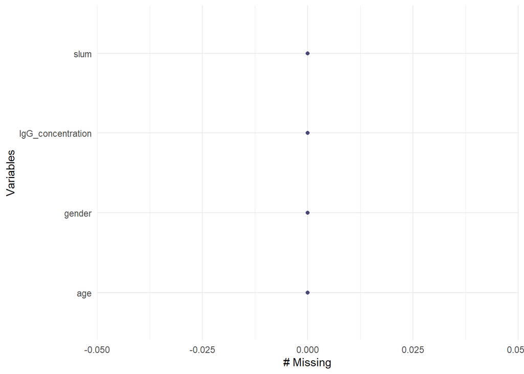

```r
naniar::gg_miss_var(sero)
```

```r
# 651 rows, 4 columns, IgG_concentration and age have numeric or double variables
#gender and slum have character variables
```

2. Create a new variable called `log_IgG_concentration` which is the log10 of `IgG_concentration` - hint: use `log10(IgG_concentration)` nested inside `mutate()` and make sure reassign it back to `sero`

```r
sero <- sero %>% mutate(log_IgG_concentration = log10(IgG_concentration))
head(sero)
```

|  | IgG_concentration | age | gender | slum | log_IgG_concentration |
| --- | --- | --- | --- | --- | --- |
| 1 | 0.31768953 | 2 | Female | Non slum | -0.4979971 |
| 2 | 3.43682310 | 4 | Female | Non slum | 0.5361572 |
| 3 | 0.30000000 | 4 | Male | Non slum | -0.5228787 |
| 4 | 143.23630137 | 4 | Male | Non slum | 2.1560531 |
| 5 | 0.44765343 | 1 | Male | Non slum | -0.3490581 |
| 6 | 0.02527076 | 4 | Male | Non slum | -1.5973817 |

3. Use `ggplot2` to create a histogram of `IgG_concentration` using `stat_bin()`. Describe the distribution of the data based on the histogram. What do we learn about the distribution of `IgG_concentration`

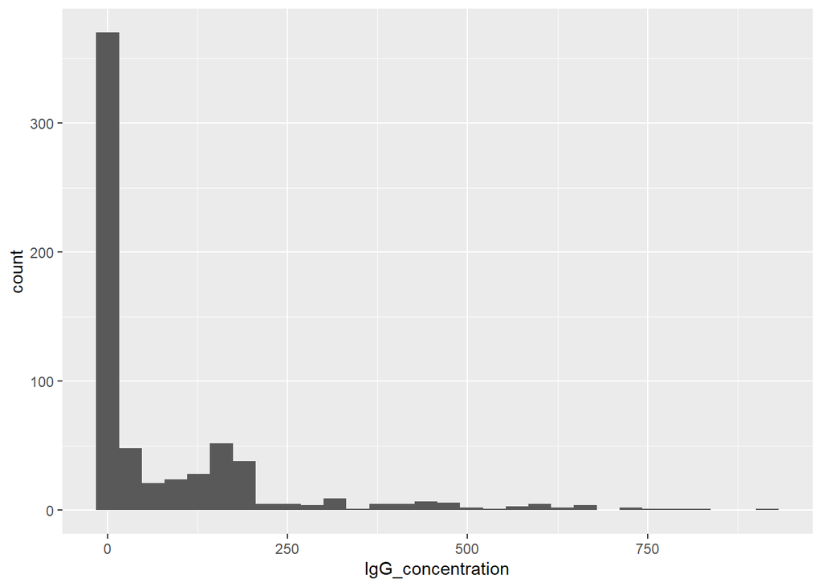

```r
ggplot(sero) +
  stat_bin(aes(x= IgG_concentration))
```

```r
#The distribution is right or positively skewed and unimodal.
```

4. Create a histogram of `log_IgG_concentration` using `stat_bin()`. IgG antibodies above a certain threshold generally represent immunity in an individual. If you were to split this bimodal distribution into two normal distributions where would you draw the threshold?

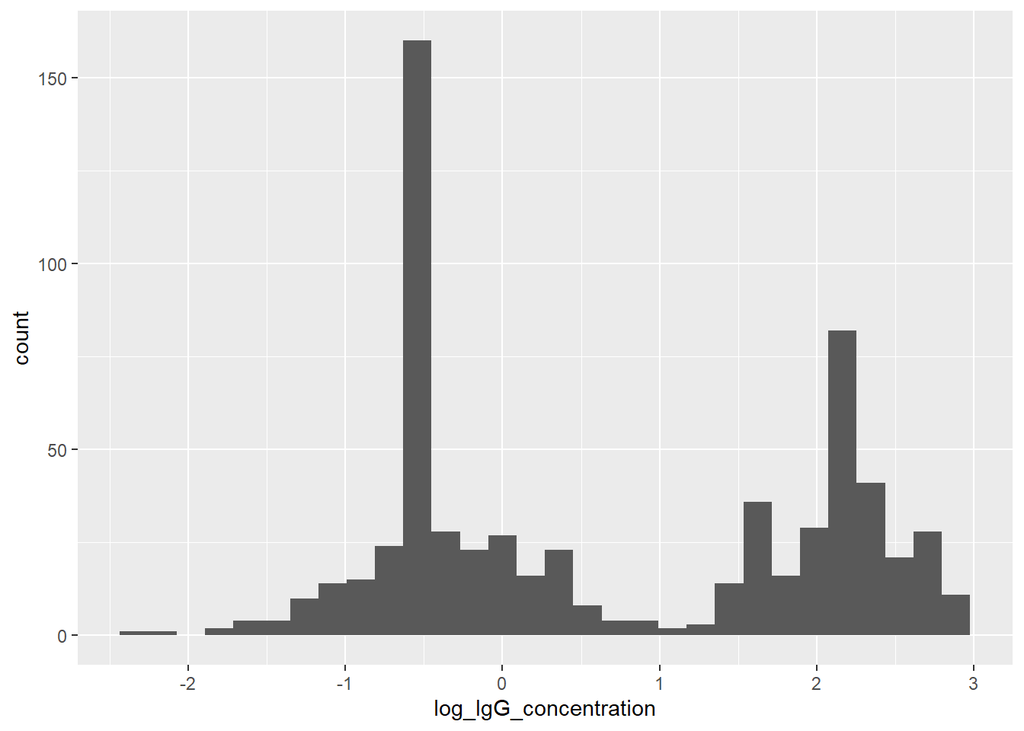

```r
ggplot(sero) +
  stat_bin(aes(x= log_IgG_concentration))
```

```r
#the threshold will be drawn at 1 to split this bimodal distribution into two normal distributions.
```

5a. Create a new variable named `sero_status` as a binary variable in which observations below the threshold are defined as 0 and observations above or equal to the threshold are defined as 1. Make sure to reassign it back to `sero` - use the `log_IgG_concentration` threshold of 1.0

```r
attach(sero)
sero$sero_status[log_IgG_concentration< 1] <- 0
sero$sero_status[log_IgG_concentration>=1] <- 1
```

5b. Output the min and max of `log_IgG_concentration` by `sero_status` to make sure the code you used in #5a worked correctly. - hint: use `group_by()` and `summarise()` creating a minimum and maximum variable using `min()` and `max()`

```r
sero %>%
  group_by(sero_status) %>%
  summarise(min(log_IgG_concentration), max(log_IgG_concentration))
```

| sero_status | min(log_IgG_concentration) | max(log_IgG_concentration) |
| --- | --- | --- |
| 0 | -2.268344 | 0.9797966 |
| 1 | 1.092907 | 2.9620936 |

6a. Create a new factor variable named `slum_binary` as a binary variable in which observations with `slum` and `mixed` values (from the `slum` variables) are defined as `slum/mixed` and observations with the `Non slum` value remain defined as `Non slum`. Make sure to reassign it back to `sero`

```r
sero <- sero %>%
  mutate(slum = factor(slum,
                       levels = c("Slum", "Mixed", "Non slum")))
levels(pull(sero, slum))
```

```
## [1] "Slum"     "Mixed"    "Non slum"
```

```r
sero <- sero %>%
  mutate(slum_binary = (recode(slum,
                       "Slum" = "slum/mixed",
                       "Mixed" = "slum/mixed",
                       "Non slum" = "Non slum")))
```

6b. Output a table of `slum` and `slum_binary` to make sure the code you used in #6a worked correctly. - hint: use `count(slum, slum_binary)`

```r
sero %>%
  mutate(slum_binary = (recode(slum,
                       "Slum" = "slum/mixed",
                       "Mixed" = "slum/mixed",
                       "Non slum" = "Non slum"))) %>%
  count(slum, slum_binary)
```

| slum | slum_binary | n |
| --- | --- | --- |
| Slum | slum/mixed | 45 |
| Mixed | slum/mixed | 135 |
| Non slum | Non slum | 471 |

7. Now let’s summarize the `sero` dataset: Calculate the proportion of observations where `sero_status` is equal to 1 grouped by `age` and `slum_binary` variables. Call the new variable `prop` & assign the new tibble to `sero_group`. Check that the number of rows in the new datset `sero_group` is 30 using `nrow()` - hint: you will need to use `group_by()` and then `summarise(prop = ...)` to create a new variable `prop`

```r
sero_group <- sero %>%
  group_by(age, slum_binary) %>%
  summarise(prop = sum(sero_status == 1)/n(),
            .groups ="drop")

nrow(sero_group)
```

```
## [1] 30
```

[figure not shown]

```r
ggplot(sero_group, aes(x=age, y=prop)) +
  geom_point() +
  stat_smooth(method="loess", col="#d53e4f", fill="#d53e4f") +
  labs(x = "proportion seropositive",
       y = "age(years)")
```

9. Using the `sero_group` dataset, create a scatter plot of `age` (x axis) and `prop` (y axis) and then add fit a line using GAM method. - use `formula = y ~ s(x, bs="cr")` - remove the 95% CI ribbon from the GAM fit - use built in ggplot theme `theme_bw()`

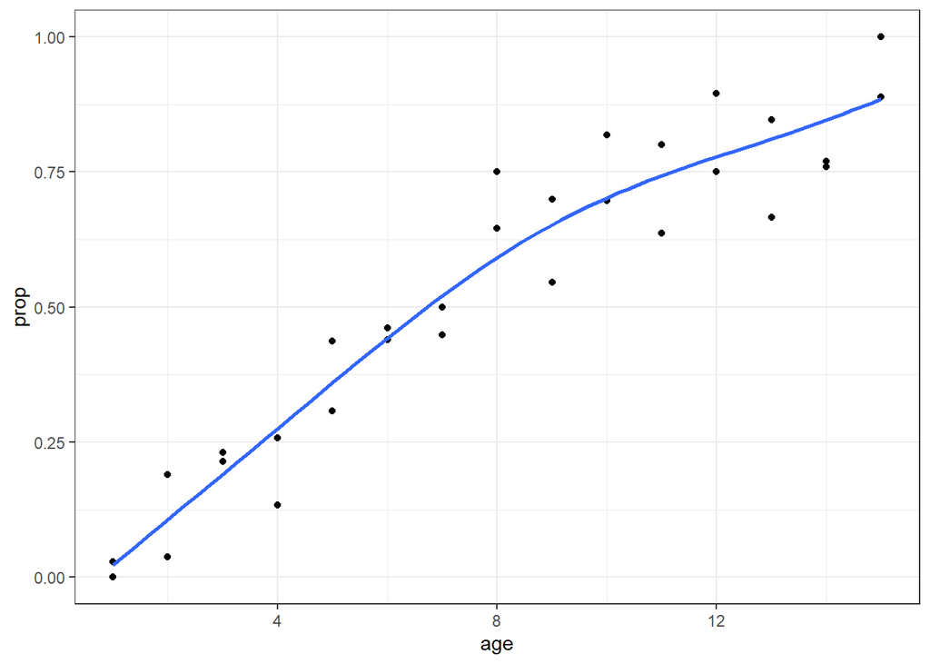

```r
ggplot(sero_group, aes(x=age, y=prop)) +
  geom_point() +
  stat_smooth(method="gam", se =FALSE, formula = y ~ s(x, bs="cr")) +
  theme_bw()
```

10. Using the `sero_group` dataset, create a scatter plot of `age` (x axis) and `prop` (y axis) grouped by `slum_binary` and then add a fit line using GAM method also for each value of the `slum_binary` variable. - hint: use `color=slum_binary` and `fill=slum_binary` as mapped aesthetics - use the RColorBrewer color palette “Set2” to for both the colors (point and fit line) and the fills (95% CI ribbon).

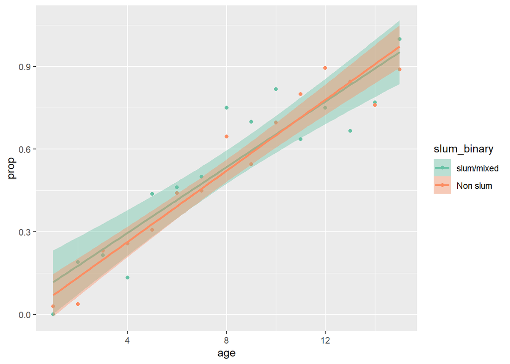

```r
 ggplot(sero_group, aes(x=age, y=prop, col=slum_binary, fill=slum_binary)) +
  geom_point() +
  stat_smooth(method="gam", formula = y ~ x) +
  scale_color_brewer(palette = "Set2") +
scale_fill_brewer(palette = "Set2")
```

11. Zoom in on the plot from #10 for ages 10 to 15 using `coord_cartesian()`

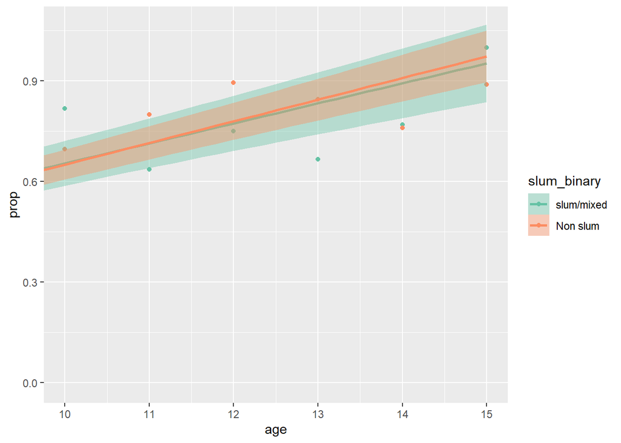

```r
ggplot(sero_group, aes(x=age, y=prop, col=slum_binary, fill=slum_binary)) +
  geom_point() +
  stat_smooth(method="gam", formula = y ~ x) +
  scale_color_brewer(palette = "Set2") +
scale_fill_brewer(palette = "Set2") +
  coord_cartesian(xlim = c(10, 15))
```

12. Make the plot from #10 easier to read using `facet_wrap()` to create a plot for each `slum_binary` value

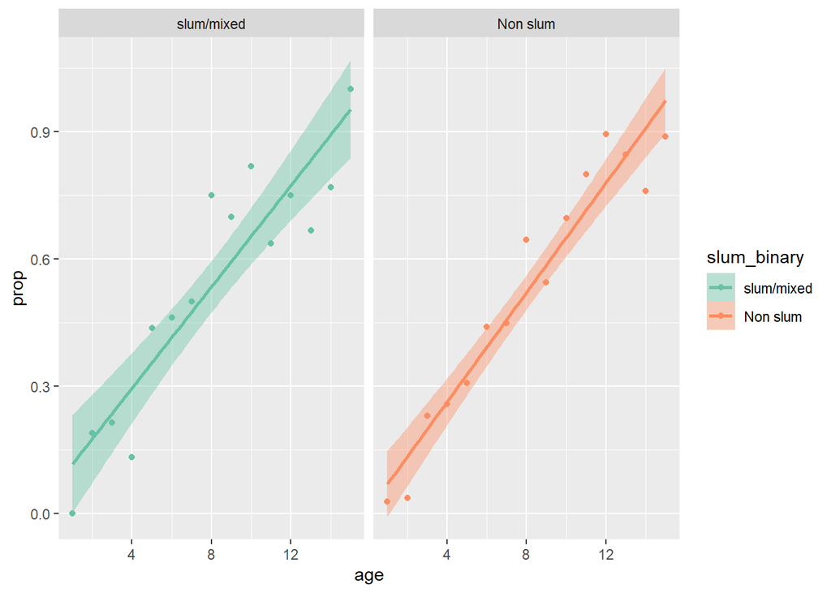

```r
ggplot(sero_group, aes(x=age, y=prop, col=slum_binary, fill=slum_binary)) +
  geom_point() +
  stat_smooth(method="gam", formula = y ~ x) +
  scale_color_brewer(palette = "Set2") +
scale_fill_brewer(palette = "Set2") +
  facet_wrap(. ~slum_binary)
```

13. Using the `sero` dataset, create a scatter plot of `log_IgG_concentration` (y axis) and `age` (x axis) using `geom_jitter()` where the alpha attribute is `geom_jitter()` is set to 0.5

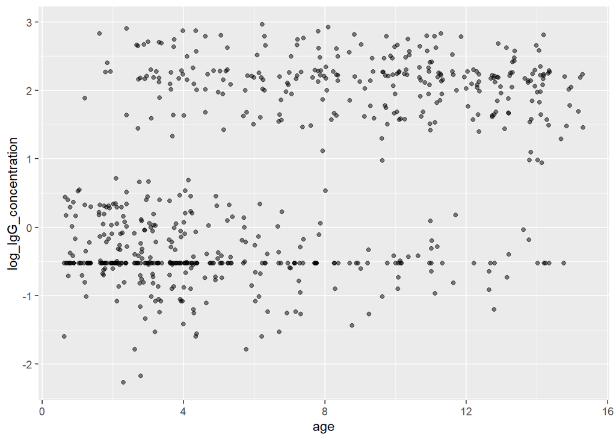

```r
ggplot(sero, aes(x=age, y=log_IgG_concentration)) +
  geom_jitter(alpha = 0.5)
```

14. Add an additional plot layer to #13 of `stat_sum()` to count the number of observations at each `age` and then map the count onto size as the point area.

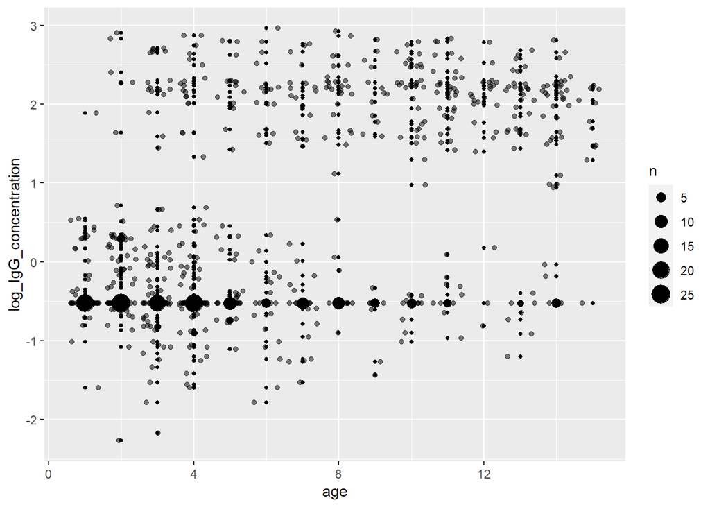

```r
ggplot(sero, aes(x=age, y=log_IgG_concentration)) +
  stat_sum() +
  geom_jitter(alpha = 0.5)
```

15. Using the `sero` dataset, plot the mean `log_IgG_concentration` (y axis) as points and 1 standard deviation plus or minus the mean `log_IgG_concentration` as vertical lines for each age in years (x axis). - hint: `stat_summary(fun.data = mean_sdl)` - hint: use the `mult` argument to specify 1 standard deviation - change the x axis ticks so that all ages 1 though 15 are displayed using `breaks()`

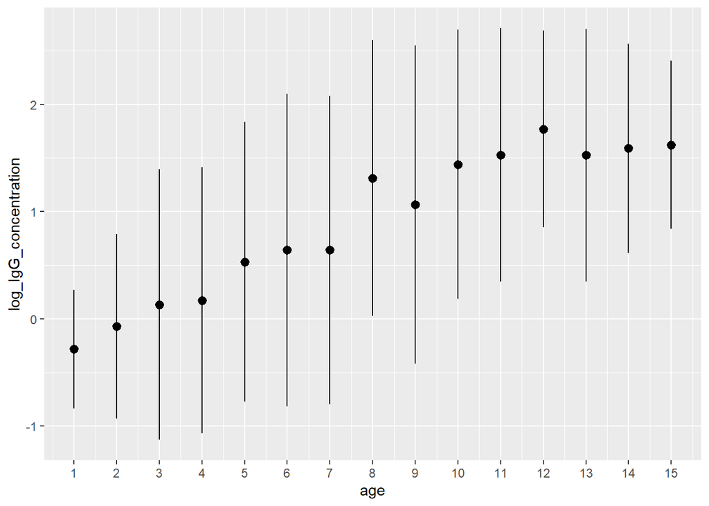

```r
ggplot(sero, aes(x = age, y = log_IgG_concentration)) +
  stat_summary(fun.data = mean_sdl, fun.args = list(mult=1)) +
    scale_x_continuous(breaks=seq(1:15))
```

16. Using the `sero` dataset, evaluate whether `log_IgG_concentration` is normally distributed among observations in which `sero_status` is equal to 1. Answer below the R chunk if it appears to be normally distributed? - hint: subset data using `filter()` to only include samples where `sero_status` is equal to 1 then use `stat_function()`

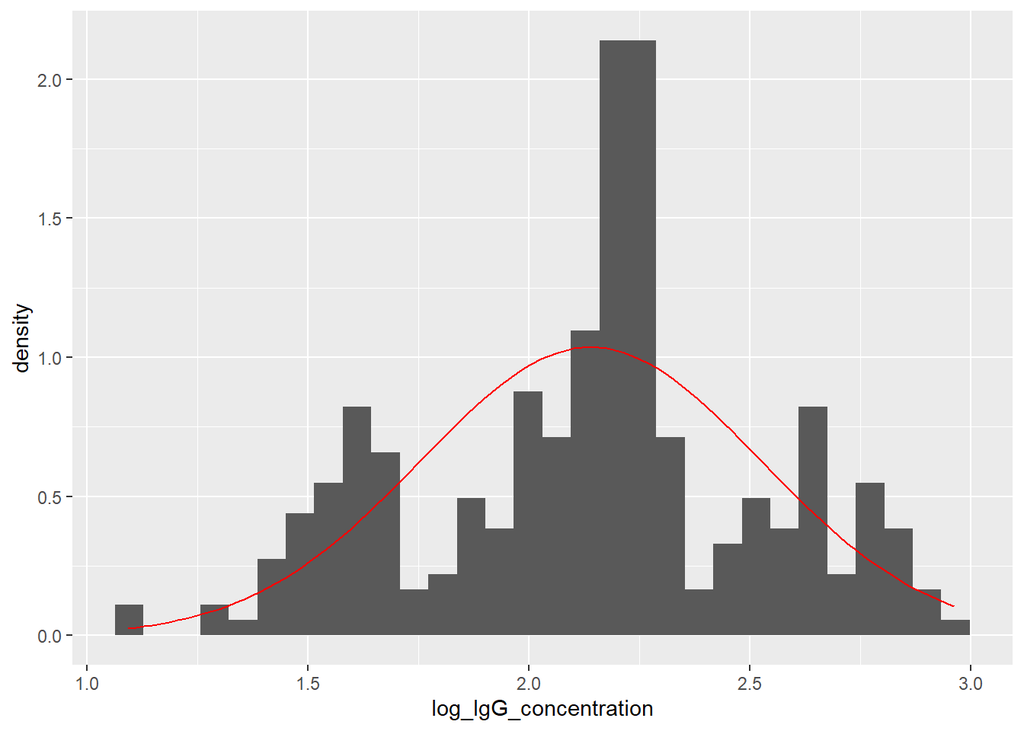

```r
sero_filter <- filter(sero, sero_status == 1)
ggplot(sero_filter, aes(x=log_IgG_concentration)) +
  geom_histogram(aes(y = ..density..)) +
  stat_function(fun = dnorm, color="red", args = list(mean = mean(sero_filter$log_IgG_concentration), sd = sd(sero_filter$log_IgG_concentration)))
```